# Risk Factor Analysis

## Outcome Variable

**Outcome Variable:** ever_swasted

## Predictor Variables

**Intervention Variable:** predfeed6

**Adjustment Set:**

unadjusted

## Stratifying Variables

The analysis was stratified on these variable(s):

- agecat
- studyid
- country

## Data Summary

| agecat | studyid | country | predfeed6 | ever_swasted | n_cell | n |
| --- | --- | --- | --- | --- | --- | --- |
| 0-24 months (no birth wast) | ki0047075b-MAL-ED | BANGLADESH | 1 | 0 | 117 | 238 |
| 0-24 months (no birth wast) | ki0047075b-MAL-ED | BANGLADESH | 1 | 1 | 8 | 238 |
| 0-24 months (no birth wast) | ki0047075b-MAL-ED | BANGLADESH | 0 | 0 | 109 | 238 |
| 0-24 months (no birth wast) | ki0047075b-MAL-ED | BANGLADESH | 0 | 1 | 4 | 238 |
| 0-24 months (no birth wast) | ki0047075b-MAL-ED | BRAZIL | 1 | 0 | 35 | 211 |
| 0-24 months (no birth wast) | ki0047075b-MAL-ED | BRAZIL | 1 | 1 | 0 | 211 |
| 0-24 months (no birth wast) | ki0047075b-MAL-ED | BRAZIL | 0 | 0 | 173 | 211 |
| 0-24 months (no birth wast) | ki0047075b-MAL-ED | BRAZIL | 0 | 1 | 3 | 211 |
| 0-24 months (no birth wast) | ki0047075b-MAL-ED | INDIA | 1 | 0 | 18 | 230 |
| 0-24 months (no birth wast) | ki0047075b-MAL-ED | INDIA | 1 | 1 | 1 | 230 |
| 0-24 months (no birth wast) | ki0047075b-MAL-ED | INDIA | 0 | 0 | 202 | 230 |
| 0-24 months (no birth wast) | ki0047075b-MAL-ED | INDIA | 0 | 1 | 9 | 230 |
| 0-24 months (no birth wast) | ki0047075b-MAL-ED | NEPAL | 1 | 0 | 29 | 235 |
| 0-24 months (no birth wast) | ki0047075b-MAL-ED | NEPAL | 1 | 1 | 0 | 235 |
| 0-24 months (no birth wast) | ki0047075b-MAL-ED | NEPAL | 0 | 0 | 203 | 235 |
| 0-24 months (no birth wast) | ki0047075b-MAL-ED | NEPAL | 0 | 1 | 3 | 235 |
| 0-24 months (no birth wast) | ki0047075b-MAL-ED | PERU | 1 | 0 | 112 | 270 |
| 0-24 months (no birth wast) | ki0047075b-MAL-ED | PERU | 1 | 1 | 2 | 270 |
| 0-24 months (no birth wast) | ki0047075b-MAL-ED | PERU | 0 | 0 | 155 | 270 |
| 0-24 months (no birth wast) | ki0047075b-MAL-ED | PERU | 0 | 1 | 1 | 270 |
| 0-24 months (no birth wast) | ki0047075b-MAL-ED | SOUTH AFRICA | 1 | 0 | 3 | 248 |
| 0-24 months (no birth wast) | ki0047075b-MAL-ED | SOUTH AFRICA | 1 | 1 | 0 | 248 |
| 0-24 months (no birth wast) | ki0047075b-MAL-ED | SOUTH AFRICA | 0 | 0 | 234 | 248 |
| 0-24 months (no birth wast) | ki0047075b-MAL-ED | SOUTH AFRICA | 0 | 1 | 11 | 248 |
| 0-24 months (no birth wast) | ki0047075b-MAL-ED | TANZANIA, UNITED REPUBLIC OF | 1 | 0 | 2 | 248 |
| 0-24 months (no birth wast) | ki0047075b-MAL-ED | TANZANIA, UNITED REPUBLIC OF | 1 | 1 | 0 | 248 |
| 0-24 months (no birth wast) | ki0047075b-MAL-ED | TANZANIA, UNITED REPUBLIC OF | 0 | 0 | 240 | 248 |
| 0-24 months (no birth wast) | ki0047075b-MAL-ED | TANZANIA, UNITED REPUBLIC OF | 0 | 1 | 6 | 248 |
| 0-24 months (no birth wast) | ki1000109-EE | PAKISTAN | 1 | 0 | 193 | 377 |
| 0-24 months (no birth wast) | ki1000109-EE | PAKISTAN | 1 | 1 | 28 | 377 |

[output cut: 126 more lines]

The following strata were considered:

- agecat: 0-24 months (no birth wast), studyid: ki0047075b-MAL-ED, country: BANGLADESH
- agecat: 0-24 months (no birth wast), studyid: ki0047075b-MAL-ED, country: BRAZIL
- agecat: 0-24 months (no birth wast), studyid: ki0047075b-MAL-ED, country: INDIA
- agecat: 0-24 months (no birth wast), studyid: ki0047075b-MAL-ED, country: NEPAL
- agecat: 0-24 months (no birth wast), studyid: ki0047075b-MAL-ED, country: PERU
- agecat: 0-24 months (no birth wast), studyid: ki0047075b-MAL-ED, country: SOUTH AFRICA
- agecat: 0-24 months (no birth wast), studyid: ki0047075b-MAL-ED, country: TANZANIA, UNITED REPUBLIC OF
- agecat: 0-24 months (no birth wast), studyid: ki1000109-EE, country: PAKISTAN
- agecat: 0-24 months (no birth wast), studyid: ki1000304b-SAS-FoodSuppl, country: INDIA
- agecat: 0-24 months (no birth wast), studyid: ki1113344-GMS-Nepal, country: NEPAL
- agecat: 0-24 months (no birth wast), studyid: ki1148112-LCNI-5, country: MALAWI
- agecat: 0-24 months (no birth wast), studyid: kiGH5241-JiVitA-3, country: BANGLADESH
- agecat: 0-24 months (no birth wast), studyid: kiGH5241-JiVitA-4, country: BANGLADESH
- agecat: 0-6 months (no birth wast), studyid: ki0047075b-MAL-ED, country: BANGLADESH
- agecat: 0-6 months (no birth wast), studyid: ki0047075b-MAL-ED, country: BRAZIL
- agecat: 0-6 months (no birth wast), studyid: ki0047075b-MAL-ED, country: INDIA
- agecat: 0-6 months (no birth wast), studyid: ki0047075b-MAL-ED, country: NEPAL
- agecat: 0-6 months (no birth wast), studyid: ki0047075b-MAL-ED, country: PERU
- agecat: 0-6 months (no birth wast), studyid: ki0047075b-MAL-ED, country: SOUTH AFRICA
- agecat: 0-6 months (no birth wast), studyid: ki0047075b-MAL-ED, country: TANZANIA, UNITED REPUBLIC OF
- agecat: 0-6 months (no birth wast), studyid: ki1000109-EE, country: PAKISTAN
- agecat: 0-6 months (no birth wast), studyid: ki1000304b-SAS-FoodSuppl, country: INDIA
- agecat: 0-6 months (no birth wast), studyid: ki1113344-GMS-Nepal, country: NEPAL
- agecat: 0-6 months (no birth wast), studyid: ki1148112-LCNI-5, country: MALAWI
- agecat: 0-6 months (no birth wast), studyid: kiGH5241-JiVitA-3, country: BANGLADESH
- agecat: 0-6 months (no birth wast), studyid: kiGH5241-JiVitA-4, country: BANGLADESH
- agecat: 6-24 months, studyid: ki0047075b-MAL-ED, country: BANGLADESH
- agecat: 6-24 months, studyid: ki0047075b-MAL-ED, country: BRAZIL
- agecat: 6-24 months, studyid: ki0047075b-MAL-ED, country: INDIA
- agecat: 6-24 months, studyid: ki0047075b-MAL-ED, country: NEPAL
- agecat: 6-24 months, studyid: ki0047075b-MAL-ED, country: PERU
- agecat: 6-24 months, studyid: ki0047075b-MAL-ED, country: SOUTH AFRICA
- agecat: 6-24 months, studyid: ki0047075b-MAL-ED, country: TANZANIA, UNITED REPUBLIC OF
- agecat: 6-24 months, studyid: ki1000109-EE, country: PAKISTAN
- agecat: 6-24 months, studyid: ki1000304b-SAS-FoodSuppl, country: INDIA
- agecat: 6-24 months, studyid: ki1113344-GMS-Nepal, country: NEPAL
- agecat: 6-24 months, studyid: ki1148112-LCNI-5, country: MALAWI
- agecat: 6-24 months, studyid: kiGH5241-JiVitA-3, country: BANGLADESH
- agecat: 6-24 months, studyid: kiGH5241-JiVitA-4, country: BANGLADESH

### Dropped Strata

Some strata were dropped due to rare outcomes:

- agecat: 0-24 months (no birth wast), studyid: ki0047075b-MAL-ED, country: BANGLADESH
- agecat: 0-24 months (no birth wast), studyid: ki0047075b-MAL-ED, country: BRAZIL
- agecat: 0-24 months (no birth wast), studyid: ki0047075b-MAL-ED, country: INDIA
- agecat: 0-24 months (no birth wast), studyid: ki0047075b-MAL-ED, country: NEPAL
- agecat: 0-24 months (no birth wast), studyid: ki0047075b-MAL-ED, country: PERU
- agecat: 0-24 months (no birth wast), studyid: ki0047075b-MAL-ED, country: SOUTH AFRICA
- agecat: 0-24 months (no birth wast), studyid: ki0047075b-MAL-ED, country: TANZANIA, UNITED REPUBLIC OF
- agecat: 0-24 months (no birth wast), studyid: ki1000304b-SAS-FoodSuppl, country: INDIA
- agecat: 0-24 months (no birth wast), studyid: ki1148112-LCNI-5, country: MALAWI
- agecat: 0-6 months (no birth wast), studyid: ki0047075b-MAL-ED, country: BANGLADESH
- agecat: 0-6 months (no birth wast), studyid: ki0047075b-MAL-ED, country: BRAZIL
- agecat: 0-6 months (no birth wast), studyid: ki0047075b-MAL-ED, country: INDIA
- agecat: 0-6 months (no birth wast), studyid: ki0047075b-MAL-ED, country: NEPAL
- agecat: 0-6 months (no birth wast), studyid: ki0047075b-MAL-ED, country: PERU
- agecat: 0-6 months (no birth wast), studyid: ki0047075b-MAL-ED, country: SOUTH AFRICA
- agecat: 0-6 months (no birth wast), studyid: ki0047075b-MAL-ED, country: TANZANIA, UNITED REPUBLIC OF
- agecat: 0-6 months (no birth wast), studyid: ki1000304b-SAS-FoodSuppl, country: INDIA
- agecat: 0-6 months (no birth wast), studyid: ki1148112-LCNI-5, country: MALAWI
- agecat: 0-6 months (no birth wast), studyid: kiGH5241-JiVitA-4, country: BANGLADESH
- agecat: 6-24 months, studyid: ki0047075b-MAL-ED, country: BANGLADESH
- agecat: 6-24 months, studyid: ki0047075b-MAL-ED, country: BRAZIL
- agecat: 6-24 months, studyid: ki0047075b-MAL-ED, country: INDIA
- agecat: 6-24 months, studyid: ki0047075b-MAL-ED, country: NEPAL
- agecat: 6-24 months, studyid: ki0047075b-MAL-ED, country: PERU
- agecat: 6-24 months, studyid: ki0047075b-MAL-ED, country: SOUTH AFRICA
- agecat: 6-24 months, studyid: ki0047075b-MAL-ED, country: TANZANIA, UNITED REPUBLIC OF
- agecat: 6-24 months, studyid: ki1000304b-SAS-FoodSuppl, country: INDIA
- agecat: 6-24 months, studyid: ki1148112-LCNI-5, country: MALAWI

## Methods Detail

We’re interested in the causal parameters $E[Y_a]$ for all values of $a \in \mathcal{A}$. These parameters represent the mean outcome if, possibly contrary to fact, we intervened to set all units to have $A=a$. Under the randomization and positivity assumptions, these are identified by the statistical parameters $\psi_a=E_W[E_{Y|A,W}(Y|A=a,W)]$. In addition, we’re interested in the mean of $Y$, $E[Y]$ under no intervention (the observed mean). We will estimate these parameters by using SuperLearner to fit the relevant likelihood factors – $E_{Y|A,W}(Y|A=a,W)$ and $p(A=a|W)$, and then updating our likelihood fit using a joint TMLE.

For unadjusted analyses ($W=\{\}$), initial likelihoods were estimated using Lrnr_glm to estimate the simple $E(Y|A)$ and Lrnr_mean to estimate $p(A)$. For adjusted analyses, a small library containing Lrnr_glmnet, Lrnr_xgboost, and Lrnr_mean was used.

Having estimated these parameters, we will then use the delta method to estimate relative risks and attributable risks relative to a prespecified baseline level of $A$.

# Results Detail

## Results Plots

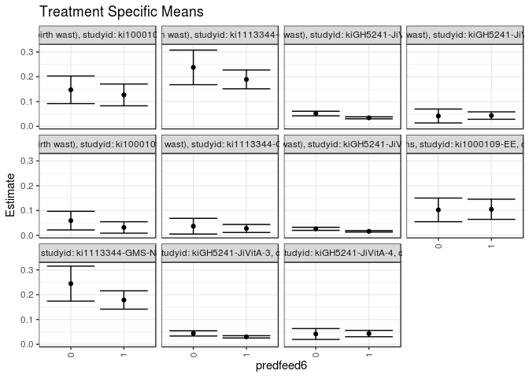

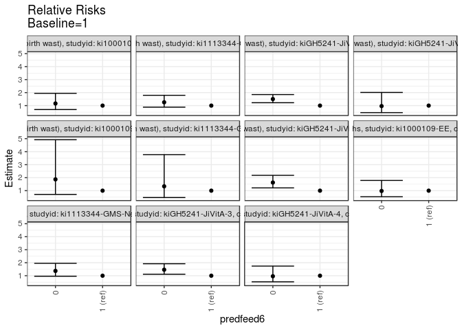

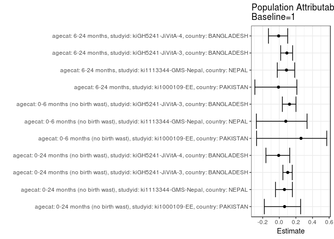

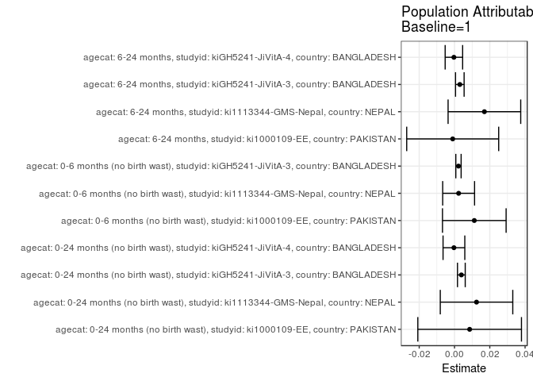

## Results Table

### Parameter: TSM

| agecat | studyid | country | intervention_level | baseline_level | estimate | ci_lower | ci_upper |
| --- | --- | --- | --- | --- | --- | --- | --- |
| 0-24 months (no birth wast) | ki1000109-EE | PAKISTAN | 1 | NA | 0.1266968 | 0.0827837 | 0.1706099 |
| 0-24 months (no birth wast) | ki1000109-EE | PAKISTAN | 0 | NA | 0.1474359 | 0.0917266 | 0.2031452 |
| 0-24 months (no birth wast) | ki1113344-GMS-Nepal | NEPAL | 1 | NA | 0.1893204 | 0.1514574 | 0.2271833 |
| 0-24 months (no birth wast) | ki1113344-GMS-Nepal | NEPAL | 0 | NA | 0.2377622 | 0.1679248 | 0.3075997 |
| 0-24 months (no birth wast) | kiGH5241-JiVitA-3 | BANGLADESH | 1 | NA | 0.0343519 | 0.0303360 | 0.0383678 |
| 0-24 months (no birth wast) | kiGH5241-JiVitA-3 | BANGLADESH | 0 | NA | 0.0516351 | 0.0424445 | 0.0608257 |
| 0-24 months (no birth wast) | kiGH5241-JiVitA-4 | BANGLADESH | 1 | NA | 0.0434783 | 0.0285844 | 0.0583721 |
| 0-24 months (no birth wast) | kiGH5241-JiVitA-4 | BANGLADESH | 0 | NA | 0.0418410 | 0.0137932 | 0.0698888 |
| 0-6 months (no birth wast) | ki1000109-EE | PAKISTAN | 1 | NA | 0.0316742 | 0.0085536 | 0.0547948 |
| 0-6 months (no birth wast) | ki1000109-EE | PAKISTAN | 0 | NA | 0.0592105 | 0.0216393 | 0.0967817 |
| 0-6 months (no birth wast) | ki1113344-GMS-Nepal | NEPAL | 1 | NA | 0.0275689 | 0.0114881 | 0.0436497 |
| 0-6 months (no birth wast) | ki1113344-GMS-Nepal | NEPAL | 0 | NA | 0.0367647 | 0.0051079 | 0.0684215 |
| 0-6 months (no birth wast) | kiGH5241-JiVitA-3 | BANGLADESH | 1 | NA | 0.0160917 | 0.0131173 | 0.0190661 |
| 0-6 months (no birth wast) | kiGH5241-JiVitA-3 | BANGLADESH | 0 | NA | 0.0261506 | 0.0199087 | 0.0323926 |
| 6-24 months | ki1000109-EE | PAKISTAN | 1 | NA | 0.1050228 | 0.0643641 | 0.1456816 |
| 6-24 months | ki1000109-EE | PAKISTAN | 0 | NA | 0.1025641 | 0.0548919 | 0.1502363 |
| 6-24 months | ki1113344-GMS-Nepal | NEPAL | 1 | NA | 0.1787440 | 0.1418043 | 0.2156836 |
| 6-24 months | ki1113344-GMS-Nepal | NEPAL | 0 | NA | 0.2447552 | 0.1742242 | 0.3152863 |
| 6-24 months | kiGH5241-JiVitA-3 | BANGLADESH | 1 | NA | 0.0301159 | 0.0256242 | 0.0346077 |
| 6-24 months | kiGH5241-JiVitA-3 | BANGLADESH | 0 | NA | 0.0440217 | 0.0334460 | 0.0545974 |
| 6-24 months | kiGH5241-JiVitA-4 | BANGLADESH | 1 | NA | 0.0432099 | 0.0304036 | 0.0560161 |
| 6-24 months | kiGH5241-JiVitA-4 | BANGLADESH | 0 | NA | 0.0414938 | 0.0195556 | 0.0634319 |

### Parameter: E(Y)

| agecat | studyid | country | intervention_level | baseline_level | estimate | ci_lower | ci_upper |
| --- | --- | --- | --- | --- | --- | --- | --- |
| 0-24 months (no birth wast) | ki1000109-EE | PAKISTAN | NA | NA | 0.1352785 | 0.1007079 | 0.1698491 |
| 0-24 months (no birth wast) | ki1113344-GMS-Nepal | NEPAL | NA | NA | 0.2018018 | 0.1683814 | 0.2352222 |
| 0-24 months (no birth wast) | kiGH5241-JiVitA-3 | BANGLADESH | NA | NA | 0.0382383 | 0.0344038 | 0.0420727 |
| 0-24 months (no birth wast) | kiGH5241-JiVitA-4 | BANGLADESH | NA | NA | 0.0431535 | 0.0297279 | 0.0565791 |
| 0-6 months (no birth wast) | ki1000109-EE | PAKISTAN | NA | NA | 0.0428954 | 0.0223052 | 0.0634857 |
| 0-6 months (no birth wast) | ki1113344-GMS-Nepal | NEPAL | NA | NA | 0.0299065 | 0.0154599 | 0.0443532 |
| 0-6 months (no birth wast) | kiGH5241-JiVitA-3 | BANGLADESH | NA | NA | 0.0183436 | 0.0155725 | 0.0211147 |
| 6-24 months | ki1000109-EE | PAKISTAN | NA | NA | 0.1040000 | 0.0730627 | 0.1349373 |
| 6-24 months | ki1113344-GMS-Nepal | NEPAL | NA | NA | 0.1956912 | 0.1627145 | 0.2286679 |
| 6-24 months | kiGH5241-JiVitA-3 | BANGLADESH | NA | NA | 0.0331329 | 0.0288237 | 0.0374420 |
| 6-24 months | kiGH5241-JiVitA-4 | BANGLADESH | NA | NA | 0.0428689 | 0.0315340 | 0.0542038 |

### Parameter: RR

| agecat | studyid | country | intervention_level | baseline_level | estimate | ci_lower | ci_upper |
| --- | --- | --- | --- | --- | --- | --- | --- |
| 0-24 months (no birth wast) | ki1000109-EE | PAKISTAN | 1 | 1 | 1.0000000 | 1.0000000 | 1.000000 |
| 0-24 months (no birth wast) | ki1000109-EE | PAKISTAN | 0 | 1 | 1.1636905 | 0.6968768 | 1.943206 |
| 0-24 months (no birth wast) | ki1113344-GMS-Nepal | NEPAL | 1 | 1 | 1.0000000 | 1.0000000 | 1.000000 |
| 0-24 months (no birth wast) | ki1113344-GMS-Nepal | NEPAL | 0 | 1 | 1.2558723 | 0.8802760 | 1.791728 |
| 0-24 months (no birth wast) | kiGH5241-JiVitA-3 | BANGLADESH | 1 | 1 | 1.0000000 | 1.0000000 | 1.000000 |
| 0-24 months (no birth wast) | kiGH5241-JiVitA-3 | BANGLADESH | 0 | 1 | 1.5031221 | 1.2225518 | 1.848082 |
| 0-24 months (no birth wast) | kiGH5241-JiVitA-4 | BANGLADESH | 1 | 1 | 1.0000000 | 1.0000000 | 1.000000 |
| 0-24 months (no birth wast) | kiGH5241-JiVitA-4 | BANGLADESH | 0 | 1 | 0.9623431 | 0.4603657 | 2.011671 |
| 0-6 months (no birth wast) | ki1000109-EE | PAKISTAN | 1 | 1 | 1.0000000 | 1.0000000 | 1.000000 |
| 0-6 months (no birth wast) | ki1000109-EE | PAKISTAN | 0 | 1 | 1.8693609 | 0.7106352 | 4.917446 |
| 0-6 months (no birth wast) | ki1113344-GMS-Nepal | NEPAL | 1 | 1 | 1.0000000 | 1.0000000 | 1.000000 |
| 0-6 months (no birth wast) | ki1113344-GMS-Nepal | NEPAL | 0 | 1 | 1.3335561 | 0.4713373 | 3.773035 |
| 0-6 months (no birth wast) | kiGH5241-JiVitA-3 | BANGLADESH | 1 | 1 | 1.0000000 | 1.0000000 | 1.000000 |
| 0-6 months (no birth wast) | kiGH5241-JiVitA-3 | BANGLADESH | 0 | 1 | 1.6250981 | 1.2121038 | 2.178810 |
| 6-24 months | ki1000109-EE | PAKISTAN | 1 | 1 | 1.0000000 | 1.0000000 | 1.000000 |
| 6-24 months | ki1000109-EE | PAKISTAN | 0 | 1 | 0.9765886 | 0.5333358 | 1.788227 |
| 6-24 months | ki1113344-GMS-Nepal | NEPAL | 1 | 1 | 1.0000000 | 1.0000000 | 1.000000 |
| 6-24 months | ki1113344-GMS-Nepal | NEPAL | 0 | 1 | 1.3693064 | 0.9604919 | 1.952125 |
| 6-24 months | kiGH5241-JiVitA-3 | BANGLADESH | 1 | 1 | 1.0000000 | 1.0000000 | 1.000000 |
| 6-24 months | kiGH5241-JiVitA-3 | BANGLADESH | 0 | 1 | 1.4617418 | 1.1113296 | 1.922642 |
| 6-24 months | kiGH5241-JiVitA-4 | BANGLADESH | 1 | 1 | 1.0000000 | 1.0000000 | 1.000000 |
| 6-24 months | kiGH5241-JiVitA-4 | BANGLADESH | 0 | 1 | 0.9602845 | 0.5298395 | 1.740426 |

### Parameter: PAR

| agecat | studyid | country | intervention_level | baseline_level | estimate | ci_lower | ci_upper |
| --- | --- | --- | --- | --- | --- | --- | --- |
| 0-24 months (no birth wast) | ki1000109-EE | PAKISTAN | 1 | NA | 0.0085817 | -0.0207892 | 0.0379526 |
| 0-24 months (no birth wast) | ki1113344-GMS-Nepal | NEPAL | 1 | NA | 0.0124814 | -0.0080631 | 0.0330259 |
| 0-24 months (no birth wast) | kiGH5241-JiVitA-3 | BANGLADESH | 1 | NA | 0.0038863 | 0.0016918 | 0.0060809 |
| 0-24 months (no birth wast) | kiGH5241-JiVitA-4 | BANGLADESH | 1 | NA | -0.0003247 | -0.0064898 | 0.0058404 |
| 0-6 months (no birth wast) | ki1000109-EE | PAKISTAN | 1 | NA | 0.0112212 | -0.0068085 | 0.0292510 |
| 0-6 months (no birth wast) | ki1113344-GMS-Nepal | NEPAL | 1 | NA | 0.0023376 | -0.0066948 | 0.0113701 |
| 0-6 months (no birth wast) | kiGH5241-JiVitA-3 | BANGLADESH | 1 | NA | 0.0022519 | 0.0007449 | 0.0037589 |
| 6-24 months | ki1000109-EE | PAKISTAN | 1 | NA | -0.0010228 | -0.0270880 | 0.0250423 |
| 6-24 months | ki1113344-GMS-Nepal | NEPAL | 1 | NA | 0.0169472 | -0.0036336 | 0.0375280 |
| 6-24 months | kiGH5241-JiVitA-3 | BANGLADESH | 1 | NA | 0.0030169 | 0.0005851 | 0.0054488 |
| 6-24 months | kiGH5241-JiVitA-4 | BANGLADESH | 1 | NA | -0.0003410 | -0.0052939 | 0.0046120 |

### Parameter: PAF

| agecat | studyid | country | intervention_level | baseline_level | estimate | ci_lower | ci_upper |
| --- | --- | --- | --- | --- | --- | --- | --- |
| 0-24 months (no birth wast) | ki1000109-EE | PAKISTAN | 1 | NA | 0.0634371 | -0.1803657 | 0.2568829 |
| 0-24 months (no birth wast) | ki1113344-GMS-Nepal | NEPAL | 1 | NA | 0.0618499 | -0.0453822 | 0.1580824 |
| 0-24 months (no birth wast) | kiGH5241-JiVitA-3 | BANGLADESH | 1 | NA | 0.1016350 | 0.0436080 | 0.1561414 |
| 0-24 months (no birth wast) | kiGH5241-JiVitA-4 | BANGLADESH | 1 | NA | -0.0075251 | -0.1609784 | 0.1256454 |
| 0-6 months (no birth wast) | ki1000109-EE | PAKISTAN | 1 | NA | 0.2615950 | -0.2734458 | 0.5718374 |
| 0-6 months (no birth wast) | ki1113344-GMS-Nepal | NEPAL | 1 | NA | 0.0781642 | -0.2761142 | 0.3340868 |
| 0-6 months (no birth wast) | kiGH5241-JiVitA-3 | BANGLADESH | 1 | NA | 0.1227614 | 0.0370273 | 0.2008626 |
| 6-24 months | ki1000109-EE | PAKISTAN | 1 | NA | -0.0098349 | -0.2942866 | 0.2121014 |
| 6-24 months | ki1113344-GMS-Nepal | NEPAL | 1 | NA | 0.0866020 | -0.0242291 | 0.1854401 |
| 6-24 months | kiGH5241-JiVitA-3 | BANGLADESH | 1 | NA | 0.0910557 | 0.0162329 | 0.1601877 |
| 6-24 months | kiGH5241-JiVitA-4 | BANGLADESH | 1 | NA | -0.0079535 | -0.1301623 | 0.1010404 |